# What is the my dataset?

[figure not shown]

The EU has adopted several amendments on its landmark EU AI Act (first of its kind regulatory framework proposed in April 2021) mainly concerning the use of Foundation models.

# Extract the data from the website

in this part we should consider the following points:

1. the starting url is https://artificialintelligenceact.com/
2. there is no need to do DFS or BFS, we can just use the links in the main page to get to the other pages (other pages may have some links together but there is no need to do that).
3. there is some other links in the main page that are not related to the main content of the website, we should consider the links with this format `^https://artificialintelligenceact.com/title-[ivx]+/.+$` (that [ivx] is a roman number).
4. in the target pages we only consider a `<div>` with `class="container main-content"` and we should ignore the other parts of the page.

to keep this document tidy, I put the code in another file and import it here. in this code:

- I use `requests` to get the content of the pages
- I use `BeautifulSoup` to parse the html content
- I use `re` to find the links with the above format
- I use `pickle` to save the data in a file (in case of any intruption in the process, I can continue from where I left)
- I use `time` to sleep between requests (to not put too much pressure on the server)
- The output is a list of lists, each list contains one page and the text of the page.

# Tokenization

[figure not shown]

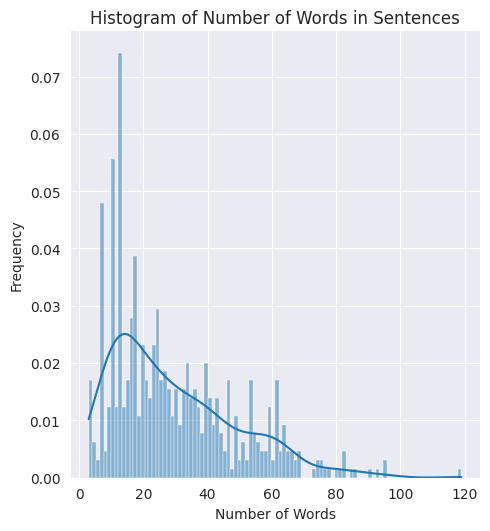

Also, it is important for us to find the number of words in each page. because the content of each page are somehow realted to each other, we use same data for training.

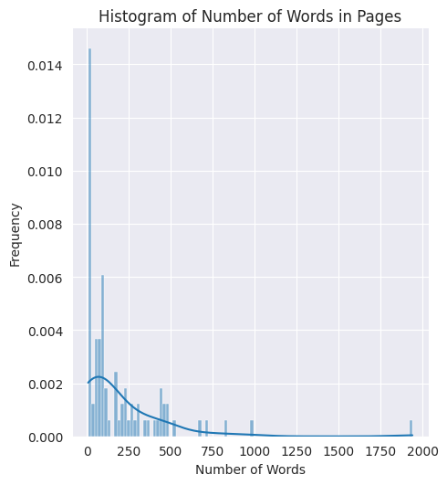

## word count

in this part we should consider the following points:

1. we should remove the punctuations
2. we should remove the stop words
3. we should remove the numbers
4. we should remove the words with length less than 3

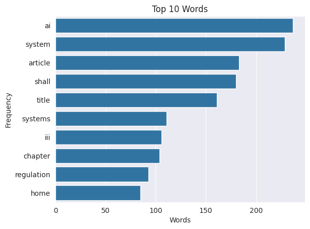

as we can see, there is a word "system" and "systems" in the list. we should consider them as one word. we can use `stemming` or `lemmatization` to do that. I have tried many different algorithms, but finally I find the `WordNetLemmatizer` the most accurate one.

### lemmatization

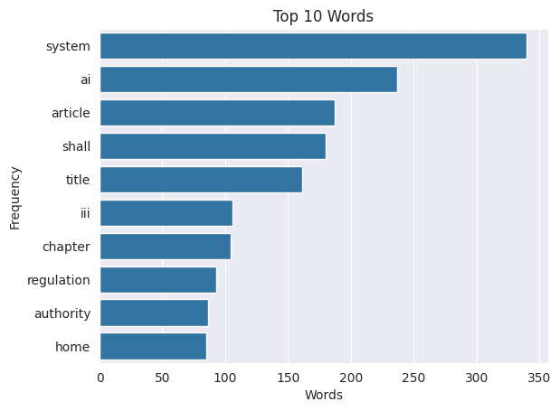

## Word Cloud

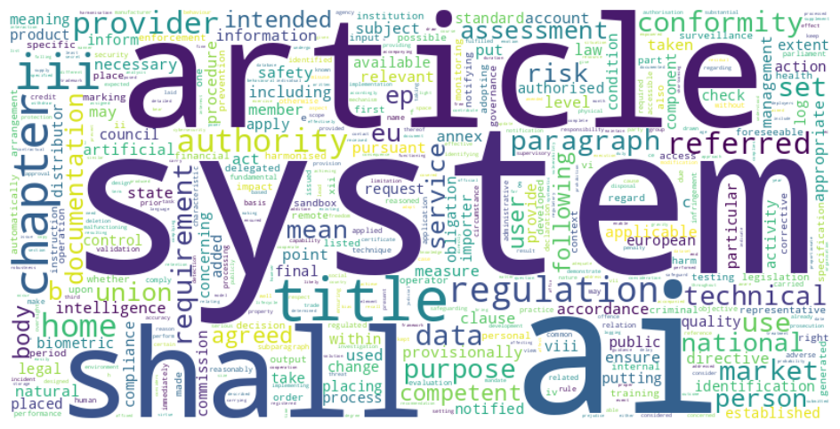

# Word embedding and PCA

[figure not shown]

## GloVe Word2Vec Embedding

The Global Vectors for word representation (GloVe), introduced by Jeffrey Pennington et al.

## PCA

PCA is a function that mapps a vector to another vector with less dimensions.

$$ \begin{align*} f:& \mathbb{R}^n \rightarrow \mathbb{R}^m, m < n \\ & x \rightarrow Mx \end{align*} $$

[figure not shown]

# Top Words density

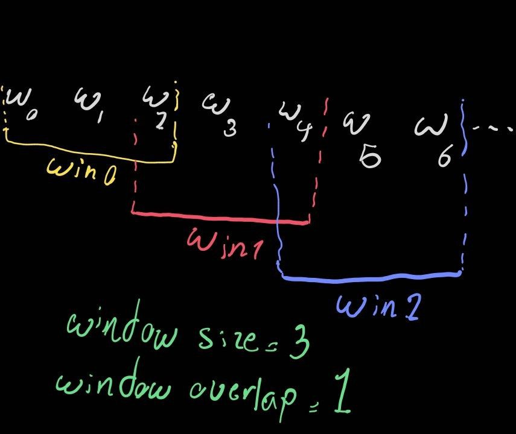

[figure not shown]

# Count 2 or 3 seccessive words

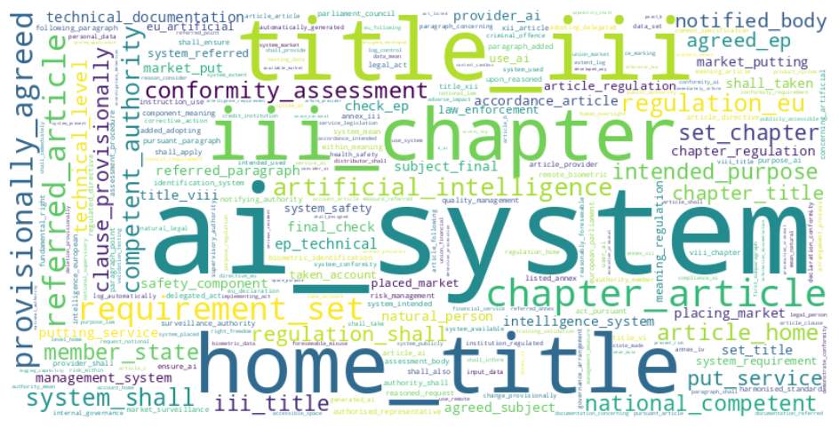

[output not shown]

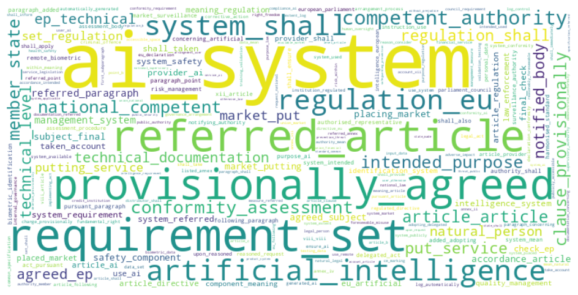

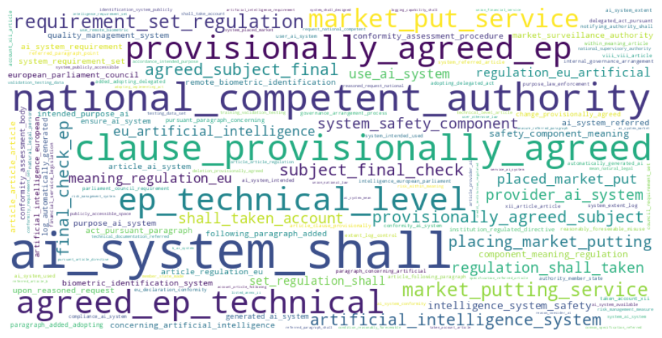

# Sentence Tree

for instance, we have the following sentences:

- I like to eat apple.
- I like to eat banana.
- I like to make pizza.
- I like winter.
- I am a human.

we can create a tree like this:

```
graph LR
A[I] ==4==> like[like]
A[I] --> E[am]
like --3--> C[to]
C --2--> D[eat]
D --> F[apple]
D --> G[banana]
C --> H[make]
H --> I[pizza]
like --> J[winter]
E --> K[a]
K --> L[human]
```

```
graph LR
N0[start] --4--> N1[like]
N1[like] --2--> N2[eat]
N2[eat] --1--> N3[apple]
N2[eat] --1--> N6[banana]
N1[like] --1--> N8[make]
N8[make] --1--> N9[pizza]
N1[like] --1--> N11[winter]
N0[start] --1--> N12[human]
N0[start] --1--> N13[name]
N13[name] --1--> N14[kasra]
```

Since we cannot see the whole tree, we can check for several sub-trees.

##### for instance, we can check for the edges which have more than 20 repetitions

```
graph LR
N15[START] --85--> N16[home]
N16[home] --85--> N17[title]
N17[title] --46--> N1518[iii]
N1518[iii] --24--> N1519[title]
N1519[title] --24--> N1520[iii]
N1520[iii] --24--> N1521[chapter]
N1521[chapter] --24--> N1522[article]
N1518[iii] --22--> N5133[chapter]
N5133[chapter] --22--> N5134[article]
N15[START] --22--> N75[provider]
N15[START] --31--> N106[system]
```

```
graph LR
N13314[START] --18--> N13315[regulation]
N13315[regulation] --5--> N19128[following]
N13314[START] --22--> N13368[provider]
N13368[provider] --7--> N16162[system]
N13314[START] --8--> N13383[user]
N13314[START] --31--> N13399[system]
N13314[START] --7--> N13579[importer]
N13314[START] --8--> N13600[distributor]
N13314[START] --6--> N13625[placing]
N13625[placing] --5--> N13626[market]
N13314[START] --7--> N13783[notifying]
N13783[notifying] --7--> N13784[authority]
N13314[START] --7--> N13800[conformity]
N13800[conformity] --5--> N13801[assessment]
N13314[START] --5--> N13989[testing]
N13314[START] --7--> N14340[following]
N14340[following] --6--> N19302[added]
N13314[START] --6--> N14700[member]
N14700[member] --6--> N14701[state]
N13314[START] --7--> N14902[extent]
N13314[START] --5--> N15037[risk]
N15037[risk] --5--> N15038[management]
N13314[START] --7--> N15180[appropriate]
N13314[START] --9--> N15505[technical]
N15505[technical] --5--> N15506[documentation]
N13314[START] --6--> N16391[clause]
N16391[clause] --6--> N16392[provisionally]
N16392[provisionally] --6--> N16393[agreed]
N16393[agreed] --6--> N16394[technical]
N16394[technical] --6--> N16395[level]
N13314[START] --7--> N16658[council]
N13314[START] --11--> N19131[adopting]
N19131[adopting] --7--> N19163[delegated]
N19163[delegated] --7--> N19164[act]
N19164[act] --7--> N19165[pursuant]
```

##### Sentence start with "system"

```
graph LR
N7199[system] --4--> N9393[designed]
N9393[designed] --4--> N9394[developed]
N9394[developed] --3--> N9486[way]
N7199[system] --3--> N9447[referred]
N9447[referred] --3--> N9448[point]
N9448[point] --3--> N9449[annex]
N7199[system] --3--> N10893[present]
N10893[present] --3--> N10894[risk]
N10894[risk] --3--> N10895[within]
N10895[within] --3--> N10896[meaning]
```

##### Sentence start with "provider"

```
graph LR
N7168[provider] --7--> N9962[system]
N7168[provider] --3--> N10467[credit]
N10467[credit] --3--> N10468[financial]
N10468[financial] --3--> N10469[institution]
N10469[institution] --3--> N10470[regulated]
N10470[regulated] --3--> N10471[directive]
N10471[directive] --3--> N10472[subject]
N10472[subject] --3--> N10473[requirement]
N10473[requirement] --3--> N10474[regarding]
N10474[regarding] --3--> N10475[internal]
N10475[internal] --3--> N10476[governance]
N10476[governance] --3--> N10477[arrangement]
N10477[arrangement] --3--> N10478[process]
N10478[process] --3--> N10479[union]
N10479[union] --3--> N10480[financial]
N10480[financial] --3--> N10481[service]
N10481[service] --3--> N10482[legislation]
```

##### Sentence start with "documentation"

```
graph LR
N10549[documentation] --4--> N10550[concerning]
N10550[concerning] --2--> N10551[quality]
N10551[quality] --2--> N10552[management]
N10552[management] --2--> N10553[system]
N10553[system] --2--> N10554[referred]
N10550[concerning] --2--> N10557[change]
N10557[change] --2--> N10558[approved]
N10558[approved] --2--> N10559[notified]
N10559[notified] --2--> N10560[body]
N10560[body] --2--> N10561[applicable]
```

##### Sentence start with "adopting"

```
graph LR
N12931[adopting] --7--> N12963[delegated]
N12963[delegated] --7--> N12964[act]
N12964[act] --7--> N12965[pursuant]
N12965[pursuant] --2--> N12966[first]
N12966[first] --2--> N12967[subparagraph]
N12967[subparagraph] --2--> N12968[concerning]
N12968[concerning] --2--> N12969[artificial]
N12969[artificial] --2--> N12970[intelligence]
N12970[intelligence] --2--> N12971[system]
N12971[system] --2--> N12972[safety]
N12972[safety] --2--> N12973[component]
N12973[component] --2--> N12974[meaning]
N12974[meaning] --2--> N12975[regulation]
N12975[regulation] --2--> N12976[artificial]
N12976[artificial] --2--> N12977[intelligence]
N12977[intelligence] --2--> N12978[european]
N12978[european] --2--> N12979[parliament]
N12979[parliament] --2--> N12980[council]
N12980[council] --2--> N12981[requirement]
N12981[requirement] --2--> N12982[set]
N12982[set] --2--> N12983[regulation]
N12983[regulation] --2--> N12984[taken]
N12984[taken] --2--> N12985[account]
N12965[pursuant] --3--> N13133[paragraph]
N13133[paragraph] --3--> N13134[concerning]
N13134[concerning] --3--> N13135[artificial]
N13135[artificial] --3--> N13136[intelligence]
N13136[intelligence] --3--> N13137[system]
N13137[system] --3--> N13138[safety]
N13138[safety] --3--> N13139[component]
N13139[component] --3--> N13140[meaning]
N13140[meaning] --3--> N13141[regulation]
N13141[regulation] --3--> N13142[artificial]
N13142[artificial] --3--> N13143[intelligence]
N13143[intelligence] --3--> N13144[requirement]
N13144[requirement] --3--> N13145[set]
N13145[set] --3--> N13146[regulation]
N13146[regulation] --3--> N13147[taken]
N13147[taken] --2--> N13148[account]
N12931[adopting] --3--> N13152[implementing]
N13152[implementing] --3--> N13153[act]
N13153[act] --2--> N13154[pursuant]
N13154[pursuant] --2--> N13155[concerning]
N13155[concerning] --2--> N13156[artificial]
N13156[artificial] --2--> N13157[intelligence]
N13157[intelligence] --2--> N13158[system]
N13158[system] --2--> N13159[safety]
N13159[safety] --2--> N13160[component]
N13160[component] --2--> N13161[meaning]
N13161[meaning] --2--> N13162[regulation]
N13162[regulation] --2--> N13163[artificial]
N13163[artificial] --2--> N13164[intelligence]
```

# Sentence Classification

In this part we want to classify the sentences based on their content.

```
graph TB
S((Start)) --> A[Grab sentence]
A --> B[Classify with ChatGpt\n with list of \navailable classes]
B --> C{If new class} --> |Yes| D[Create new class]
C --> |No| E[Add sentence to the class]
D --> E
E --> A
```

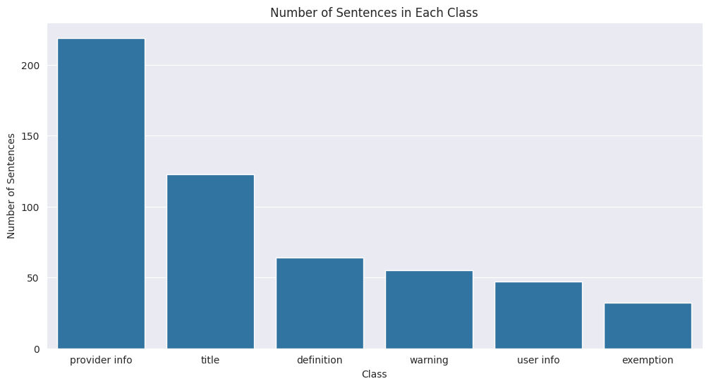

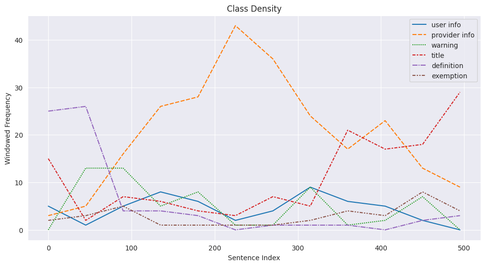

# Future Work

1. Use ChatGPT-4 for classification
2. Word count for each class
3. perform a *Named entity recognition* (NER) on the dataset
4. Use tf/idf to find the most important words in each class